# Introducción al Análisis exploratorio

Clases - Eva

Author

Betsy Cohen

Published

June 18, 2025

## Acerca del dataset

El Programa de Educación Olímpica 2018, en Argentina, fue un esfuerzo conjunto entre la Secretaría de Deporte, Educación Física y Recreación de la Nación, el Comité Olímpico Argentino (COA) y el Comité Organizador de los Juegos Olímpicos de la Juventud. Este programa, que culminó en el [Campus 2018,](https://www.argentina.gob.ar/noticias/campus-2018) buscó promover la educación olímpica a través de la integración de deporte, cultura y valores olímpicos.

El dataset que exploraremos contiene Información sobre el programa de educación olímpica: Recorrido de la Bandera Olímpica, Obras de teatro “valores olímpicos” y Murales.

## Importación incial

En este caso los datos se encuentran en formato csv y los traigo directamente del sitio de datos abiertos de la ciudad

```r
library(tidyverse) # para transformación
library(janitor)
library(zoo) # Más funciones de fechas (complementa lubridate de tidyverse)
library(gt) # Hermoseo de una tabla
library(gtExtras)
library(DataExplorer)


df <- read.csv("https://cdn.buenosaires.gob.ar/datosabiertos/datasets/vicejefatura-de-gobierno/legado-juegos-olimpicos-de-la-juventud-2018/programa-de-educacion-olimpica.csv") %>%
  janitor::clean_names()
```

Hay muchas formas de resumir o tener un primer paneo de los datos. La más habitual es el uso de la función `summary()`

```r
summary(df)
```

```
   proyecto           detalle          nombre_establecimiento
 Length:959         Length:959         Length:959
 Class :character   Class :character   Class :character
 Mode  :character   Mode  :character   Mode  :character




  direccion               x                y          nivel_modal
 Length:959         Min.   :-58.53   Min.   :-34.69   Length:959
 Class :character   1st Qu.:-58.48   1st Qu.:-34.64   Class :character
 Mode  :character   Median :-58.45   Median :-34.62   Mode  :character
                    Mean   :-58.45   Mean   :-34.62
                    3rd Qu.:-58.41   3rd Qu.:-34.60
                    Max.   :-58.36   Max.   :-34.54
                    NA's   :10       NA's   :10
 dependencia_funcional tipo_establecimiento cantidad_beneficiarios
 Length:959            Length:959           Min.   :  0.0
 Class :character      Class :character     1st Qu.: 40.0
 Mode  :character      Mode  :character     Median :250.0
                                            Mean   :187.6
                                            3rd Qu.:300.0
                                            Max.   :300.0

   mes_ano             fecha
 Length:959         Length:959
 Class :character   Class :character
 Mode  :character   Mode  :character
```

El paquete `skimr`es una alternativa que nos ofrece un resumen ordenado y elegante

```r
skimr::skim(df)
```

Data summary

| Name | df |
| --- | --- |
| Number of rows | 959 |
| Number of columns | 12 |
| _______________________ |  |
| Column type frequency: |  |
| character | 9 |
| numeric | 3 |
| ________________________ |  |
| Group variables | None |

**Variable type: character**

| skim_variable | n_missing | complete_rate | min | max | empty | n_unique | whitespace |
| --- | --- | --- | --- | --- | --- | --- | --- |
| proyecto | 0 | 1 | 7 | 23 | 0 | 6 | 0 |
| detalle | 0 | 1 | 0 | 492 | 16 | 7 | 0 |
| nombre_establecimiento | 0 | 1 | 3 | 92 | 0 | 561 | 0 |
| direccion | 0 | 1 | 7 | 44 | 0 | 540 | 0 |
| nivel_modal | 0 | 1 | 0 | 21 | 4 | 9 | 0 |
| dependencia_funcional | 0 | 1 | 0 | 14 | 21 | 4 | 0 |
| tipo_establecimiento | 0 | 1 | 0 | 63 | 184 | 26 | 0 |
| mes_ano | 0 | 1 | 5 | 7 | 0 | 51 | 0 |
| fecha | 0 | 1 | 6 | 10 | 0 | 367 | 0 |

**Variable type: numeric**

| skim_variable | n_missing | complete_rate | mean | sd | p0 | p25 | p50 | p75 | p100 | hist |
| --- | --- | --- | --- | --- | --- | --- | --- | --- | --- | --- |
| x | 10 | 0.99 | -58.45 | 0.04 | -58.53 | -58.48 | -58.45 | -58.41 | -58.36 | ▃▇▆▅▃ |
| y | 10 | 0.99 | -34.62 | 0.03 | -34.69 | -34.64 | -34.62 | -34.60 | -34.54 | ▃▆▇▅▁ |
| cantidad_beneficiarios | 0 | 1.00 | 187.57 | 110.36 | 0.00 | 40.00 | 250.00 | 300.00 | 300.00 | ▅▁▁▁▇ |

**Important¿Qué ves en este dataset?**

Hacé una lectura de los datos que estamos viendo en este primer resumen.

¿Qué representan los valores `x` e `y?`

¿Qué pasa con la variable fecha?

¿Cómo puedo detectar un caso perdido si mi variable es de tipo `character`?

### Transformación de variables

Muchas veces las variables no vienen en los formatos en los cuales las necesitamos para trabajar. Pare ello es importante planificar las trensaformaciones que necesitamos hacer:

- Poner las variables en su formato correspondiente
- Volver a revisar valores faltantes o poco utiles
- Creare nuevas variables de agrupamiento para responder a las preguntas puntuales

#### Variables categoricas

Antes de convertirlas voy a tratar de salvar cualquier error que tengan

**Uso de `mutate()` con `as.factor()`**

Para convertir a las variables de texto en categóricas y explorar las frecuencias de sus categóras podemos hacerlo una por una con el uso combinado de `mutate()` con `as.factor()

```r
df %>%
  mutate(proyecto = as.factor(proyecto),
         nivel_modal = factor(nivel_modal)) %>%
  select(proyecto,nivel_modal) %>%
  summary()
```

```
                    proyecto                  nivel_modal
 INAUGURACION MURAL     : 13   PRIMARIA             :796
 MURALES                : 39   SECUNDARIA           : 60
 OBRA DE TEATRO         :324   PRIMARIA Y SECUNDARIA: 48
 OBRA DE TEATRO         :  2   0                    : 43
 RECORRIDO DE LA BANDERA:579   PRIMARIO Y SECUNDARIO:  5
 TALLER DE GENERO       :  2                        :  4
                               (Other)              :  3
```

Si tenemos muchas variables categóricas podemos ayudarnos con el uso de `across()`el cual aplica una función (en este caso `factor`) a un conjunto de columnas

```r
# Como puedo tener muchas variables que sean categóricas creo un vector con todas ellas
variables_categoricas <-c('proyecto','nivel_modal','dependencia_funcional','tipo_establecimiento')


df %>%
  mutate( # modificar columnas con mutate()
    across(c(variables_categoricas),factor) # a lo largo de las variables categóricas
    ) %>%
  select(all_of(variables_categoricas)) %>%
  summary()
```

```
                    proyecto                  nivel_modal
 INAUGURACION MURAL     : 13   PRIMARIA             :796
 MURALES                : 39   SECUNDARIA           : 60
 OBRA DE TEATRO         :324   PRIMARIA Y SECUNDARIA: 48
 OBRA DE TEATRO         :  2   0                    : 43
 RECORRIDO DE LA BANDERA:579   PRIMARIO Y SECUNDARIO:  5
 TALLER DE GENERO       :  2                        :  4
                               (Other)              :  3
    dependencia_funcional
               : 21
 NO CORRESPONDE: 31
 PRIVADA       : 62
 PUBLICA       :845



                                                      tipo_establecimiento
 JC (ESCUELA DE JORNADA COMPLETA)                               :321
 JS (ESCUELA DE JORNADA SIMPLE)                                 :244
                                                                :184
 IEIEO (INSTITUTO EDUCATIVO INCORPORADO A LA ENSEÃ‘ANZA OFICIAL): 41
 PUBLICA                                                        : 41
 NO CORRESPONDE                                                 : 31
 (Other)                                                        : 97
```

Ahora podemos ver que hay algunas categorías que están escritas de manera diferente, y que efectivamente hay casos perdidos. Vamos a corregirlos

**Corregir errores de con if_else** Podemos hacerlo de manera manual

```r
df %>%
  mutate(
    proyecto = if_else(proyecto == "OBRA DE TEATRO ","OBRA DE TEATRO",proyecto)) %>%
  group_by(proyecto) %>%
  count()
```

| proyecto | n |
| --- | --- |
| INAUGURACION MURAL | 13 |
| MURALES | 39 |
| OBRA DE TEATRO | 326 |
| RECORRIDO DE LA BANDERA | 579 |
| TALLER DE GENERO | 2 |

o por ej si vemos que es un error sistemático como que tienen un espacio al final podemos buscar una función que corrija de manera sistemática el error

str_trim() elimina caracteres a la derecho o izquierda o en ambos al rededor de una cadena de caracteres

```r
df  <- df %>%
  mutate(
    proyecto = str_trim(proyecto, side = "both")  # elimina espacios al principio y al final
  )


df %>%
  group_by(proyecto) %>%
  count()
```

| proyecto | n |
| --- | --- |
| INAUGURACION MURAL | 13 |
| MURALES | 39 |
| OBRA DE TEATRO | 326 |
| RECORRIDO DE LA BANDERA | 579 |
| TALLER DE GENERO | 2 |

**Tip**

Esta limpieza (str_trim) es buena práctica al principio de cualquier análisis con texto porque esos espacios invisibles suelen sabotear agrupamientos, joins, filtros, etc.

**Corregir errores de escritura con case_when()**

```r
df %>%
  mutate(nivel_modal = factor(nivel_modal)) %>%
  group_by(nivel_modal) %>%
  count()
```

| nivel_modal | n |
| --- | --- |
|  | 4 |
| 0 | 43 |
| 1 | 1 |
| PRIMARIA | 796 |
| PRIMARIA Y SECUNDARIA | 48 |
| PRIMARIO | 1 |
| PRIMARIO ESPECIAL | 1 |
| PRIMARIO Y SECUNDARIO | 5 |
| SECUNDARIA | 60 |

Chequeo que son los 0 y 1 y “”

```r
#| label: analisis-perdidos-nivel-modal

df %>%
  filter(nivel_modal %in% c(0,1,"")) %>%
  group_by(tipo_establecimiento,nombre_establecimiento) %>%
  count()
```

| tipo_establecimiento | nombre_establecimiento | n |
| --- | --- | --- |
|  | ESC. DE COMERCIO N° 01 JOAQUIN V. GONZALEZ | 1 |
|  | ESC. DE COMERCIO N° 31 NACIONES UNIDAS | 1 |
|  | ESC. PRIMARIA P/ADULTOS N° 03 CRISTOBAL COLON | 1 |
|  | ESCUELA MI LUGAR (HAMAKOM SHELI) | 1 |
| CBO (CICLO BASICO DE FORMACION OCUPACIONAL) | CICLO BASICO DE FORMACION OCUPACIONAL NRO 04 PAULO FREIRE | 2 |
| DOM (ESCUELA DOMICILIARIA) | ESC. DOMICILIARIA N° 01 SEDE | 1 |
| EEE (ESCUELA DE EDUCACION ESPECIAL) | ESC. INFANTIL ESPECIAL N° 27 DRA. LIDIA F. DE CORIAT - GABINETE MATERNO INFANTIL DE18 | 1 |
| EI (ESCUELA INFANTIL) | ESCUELA INFANTIL NRO 05/21° HEBE SAN MARTIN DUPRAT | 3 |
| EI (ESCUELA INFANTIL) | ESCUELA INFANTIL N° 04/11° | 1 |
| EI (ESCUELA INFANTIL) | ESCUELA INFANTIL N° 11/20° | 1 |

[output cut: 14 more lines]

Re clasifico con diferentes criterios basados en a exploración

```r
df <- df %>%
  mutate(nivel_modal = case_when(
    nivel_modal %in% c('PRIMARIA','PRIMARIO','PRIMARIO ESPECIAL')          ~ "PRIMARIA",
    nivel_modal %in% c('PRIMARIA Y SECUNDARIA', 'PRIMARIO Y SECUNDARIO')   ~ "SECUNDARIA",
    nivel_modal == 1 & tipo_establecimiento == "EI (ESCUELA INFANTIL)"     ~ "INICIAL",
    str_starts("JC",tipo_establecimiento)                                 ~ "PRIMARIA",
    nivel_modal == 0 & tipo_establecimiento == "NO CORRESPONDE"            ~ NA_character_,
    TRUE ~ "OTRA MODALIDAD"))


# chequeo
df%>%
  group_by(nivel_modal,tipo_establecimiento) %>%
  count()
```

| nivel_modal | tipo_establecimiento | n |
| --- | --- | --- |
| OTRA MODALIDAD | CBO (CICLO BASICO DE FORMACION OCUPACIONAL) | 2 |
| OTRA MODALIDAD | COL (COLEGIO) | 13 |
| OTRA MODALIDAD | DOM (ESCUELA DOMICILIARIA) | 1 |
| OTRA MODALIDAD | EC (ESCUELA DE COMERCIO) | 17 |
| OTRA MODALIDAD | EEE (ESCUELA DE EDUCACION ESPECIAL) | 1 |
| OTRA MODALIDAD | EEM (ESCUELA DE EDUCACION MEDIA) | 4 |
| OTRA MODALIDAD | EI (ESCUELA INFANTIL) | 6 |
| OTRA MODALIDAD | ENS (ESCUELA NORMAL SUPERIOR) | 1 |
| OTRA MODALIDAD | ESEA (ESCUELA SUPERIOR DE EDUCACION ARTISTICA) | 2 |
| OTRA MODALIDAD | IEIEO (INSTITUTO EDUCATIVO INCORPORADO A LA ENSEÃ‘ANZA OFICIAL) | 6 |

[output cut: 26 more lines]

ahora las categorias van a ser solamente:

```r
df%>%
  group_by(nivel_modal) %>%
  count()
```

| nivel_modal | n |
| --- | --- |
| OTRA MODALIDAD | 71 |
| PRIMARIA | 804 |
| SECUNDARIA | 53 |
| NA | 31 |

y los NA son representativos de que esos espacios no pertenecen efectivamente a un espacio educativo

> Este tipo de correciones se puede seguir haciendo con el resto de las variables como dependencia funcional, tipo establecimiemto etc.

Terminamos de estructurar las variables categóricas como tales

```r
df <- df %>%
  mutate(across(variables_categoricas,factor))
```

#### Variables fecha

La variable fecha mezcla diferentes formatos

31-10-16 Jan-15 11/14/2015 06-06-2018

para repararlo vamos a aplicar str_detect y dplyr y lubridate

```r
df <- df %>%
  mutate(
    fecha_estandar = case_when(
      str_detect(fecha, "^\\d{1,2}/\\d{1,2}/\\d{2,4}$") ~ mdy(fecha),      # 12/15/15 o 5/24/2017
      str_detect(fecha, "^\\d{1,2}-\\d{1,2}-\\d{4}$") ~ dmy(fecha),        # 6-7-2017 o 30-7-2016
      str_detect(fecha, "^\\d{1,2}-\\d{1,2}-\\d{2}$") ~ dmy(fecha),        # 31-10-16
      str_detect(fecha, "^[A-Za-z]{3}-\\d{2}$") ~ my(fecha),               # Jan-15
      TRUE ~ as.Date(NA)  # si no matchea, lo dejamos en NA
    )
  )
df %>%
  select(fecha,fecha_estandar) %>%
  slice_sample(n = 20)
```

| fecha | fecha_estandar |
| --- | --- |
| 08-07-2017 | 2017-07-08 |
| 02-11-16 | 2016-11-02 |
| 01-04-2017 | 2017-04-01 |
| 20-04-16 | 2016-04-20 |
| Jul-15 | 2015-07-01 |
| 09-05-16 | 2016-05-09 |
| 14-09-16 | 2016-09-14 |
| 30-11-16 | 2016-11-30 |
| 13-11-2017 | 2017-11-13 |
| 01-05-2017 | 2017-05-01 |

[output cut: 10 more lines]

### Creación de variables auxiliares

Ahora podemos crear variables de mes y año como numero y/o como etiqueta.

```r
df <- df %>%
  mutate(anio = year(fecha_estandar),
         mes_numero = month(fecha_estandar),
         mes_nombre = month(fecha_estandar,label = TRUE),
         anio_mes_nombre = as.yearmon(as.character(fecha_estandar)))

df %>%
  select(fecha_estandar,anio,mes_numero,mes_nombre,anio_mes_nombre) %>%
  slice_sample(n=20)
```

| fecha_estandar | anio | mes_numero | mes_nombre | anio_mes_nombre |
| --- | --- | --- | --- | --- |
| 2016-08-15 | 2016 | 8 | ago | ago. 2016 |
| 2016-10-31 | 2016 | 10 | oct | oct. 2016 |
| 2016-04-29 | 2016 | 4 | abr | abr. 2016 |
| 2017-10-20 | 2017 | 10 | oct | oct. 2017 |
| 2017-06-28 | 2017 | 6 | jun | jun. 2017 |
| 2017-03-01 | 2017 | 3 | mar | mar. 2017 |
| 2016-04-20 | 2016 | 4 | abr | abr. 2016 |
| 2016-05-09 | 2016 | 5 | may | may. 2016 |
| 2016-09-23 | 2016 | 9 | sep | sep. 2016 |
| 2016-11-14 | 2016 | 11 | nov | nov. 2016 |

[output cut: 10 more lines]

Y creamos una clave compuesta única por proyecto, lugar y fecha para poder identificar cada proyecto.

```r
df <- df %>%
  mutate(id_proyecto = str_c(proyecto, nombre_establecimiento, fecha_estandar, sep = " - "))


df %>% select(id_proyecto) %>% head()
```

|  | id_proyecto |
| --- | --- |
| 1 | MURALES - PARQUE ROCA - 2015-01-01 |
| 2 | MURALES - PARQUE CHACABUCO - 2015-01-01 |
| 3 | MURALES - PARQUE DE LA CIUDAD - 2015-01-01 |
| 4 | MURALES - KDT - 2015-01-01 |
| 5 | MURALES - PARQUE AVELLANEDA - 2015-01-01 |
| 6 | MURALES - ESC. PRIMARIA COMUN NRO 19 HERMANOS LATINOAMERICANOS - 2015-01-12 |

eliminamos las variables que son redundantes tras la transformación

```r
df <- df %>%
  select(-fecha,mes_ano)
```

## Análisis exploratorio

¿Qué buscamos en el análisis exploratorio?

- Ver las frecuencias, estadísticos de resumen como medias, modas, rangos inter cuartiles, rangos, etc.
- Crear visualizaciones de datos

La forma en que estructuramos el análisis depende mucho del tipo de trabajo.

- Formularios /Encuestas/ KIPs predeterminados (análisis ya está guiado un poco `por las propias preguntas)
- Fuentes secundarias Formularios / Registros (Estudios más exploratorios )
- Exploración como paso intermedio para otra

### Exploración con dplyr

¿Cuál fue el alcance de los proyectos a lo largo de los años?

```r
df %>%
  group_by(anio) %>%
  summarise(beneficiarios = sum(cantidad_beneficiarios,na.rm = T),
            instituciones = n_distinct(nombre_establecimiento),
            suma_proyectos = n_distinct(id_proyecto),
            alcance_proyecto = round(beneficiarios/ suma_proyectos),
            alcance_promedio = mean(alcance_proyecto),
            alcance_mediana = median(cantidad_beneficiarios)
            ) %>%
  select(-alcance_proyecto) %>%
  gt() %>%
  tab_header(title = "Alcance del Programa de Educación Olímpica 2018") %>%
  cols_label(anio = "Año",
             suma_proyectos = "Proyectos",
             beneficiarios = "Beneficiarios",
             instituciones = "Instituciones",
             alcance_promedio = "Promedio",
             alcance_mediana = "Mediana") %>%
  tab_spanner(label = "Alcance", columns = starts_with("alcance")) %>%
  tab_footnote("Fuente: Datos abiertos Gobierno de la Ciudad de Buenos Aires")
```

Alcance del Programa de Educación Olímpica 2018

| Año | Beneficiarios | Instituciones | Proyectos | Alcance Promedio | Alcance Mediana |
| --- | --- | --- | --- | --- | --- |
| 2015 | 26235 | 142 | 196 | 134 | 60 |
| 2016 | 46545 | 270 | 329 | 141 | 40 |
| 2017 | 96680 | 227 | 340 | 284 | 300 |
| 2018 | 9570 | 36 | 40 | 239 | 250 |
| 2020 | 550 | 2 | 2 | 275 | 275 |
| 2021 | 300 | 1 | 1 | 300 | 300 |

Fuente: Datos abiertos Gobierno de la Ciudad de Buenos Aires

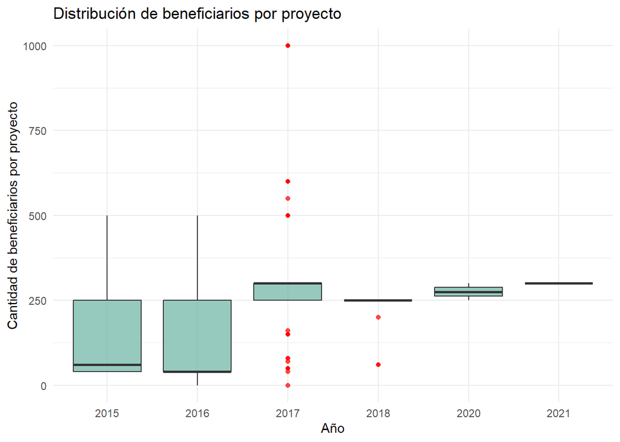

```r
df %>%
  group_by(anio, id_proyecto) %>%
  summarise(beneficiarios = sum(cantidad_beneficiarios, na.rm = TRUE), .groups = "drop") %>%
  ggplot(aes(x = factor(anio), y = beneficiarios)) +
  geom_boxplot(fill = "#69b3a2", alpha = 0.7, outlier.color = "red") +
  labs(
    title = "Distribución de beneficiarios por proyecto",
    x = "Año",
    y = "Cantidad de beneficiarios por proyecto"
  ) +
  #geom_jitter(width = 0.2, alpha = 0.3)+
  theme_minimal()
```

Esto debe leerse en función de los tipos de espacio ¿Hubo una decisión de hacer menos eventos en espacios más grandes?

```r
df %>%
  tabyl(nivel_modal,anio) %>%
  adorn_percentages('col') %>%
  adorn_pct_formatting()
```

| nivel_modal | 2015 | 2016 | 2017 | 2018 | 2020 | 2021 |
| --- | --- | --- | --- | --- | --- | --- |
| OTRA MODALIDAD | 5.5% | 13.6% | 3.7% | 0.0% | 0.0% | 0.0% |
| PRIMARIA | 92.0% | 71.7% | 90.2% | 85.0% | 100.0% | 100.0% |
| SECUNDARIA | 0.0% | 9.1% | 4.2% | 15.0% | 0.0% | 0.0% |
| NA | 2.5% | 5.6% | 1.9% | 0.0% | 0.0% | 0.0% |

😲 Para nada! Los años en los que se trabajo en parques y en el CCK (que podríamos pensar como espacios más grandes) fueron justamente los primeros dos del programa.

### Exploración con DataExplorer

Le pedimos una primera estructura de los datos (ahora ya limpios)

#### Estructura del dataset

Como a veces podemos tener más de uno…

```r
plot_str(df)
```

[output not shown]

```r
introduce(df)
```

| rows | columns | discrete_columns | continuous_columns | all_missing_columns | total_missing_values | complete_rows | total_observations | memory_usage |
| --- | --- | --- | --- | --- | --- | --- | --- | --- |
| 959 | 17 | 12 | 5 | 0 | 51 | 922 | 16303 | 374728 |

Nos hace un recuento de la situación general de columnas que estan completas valores perdidos en el dataset

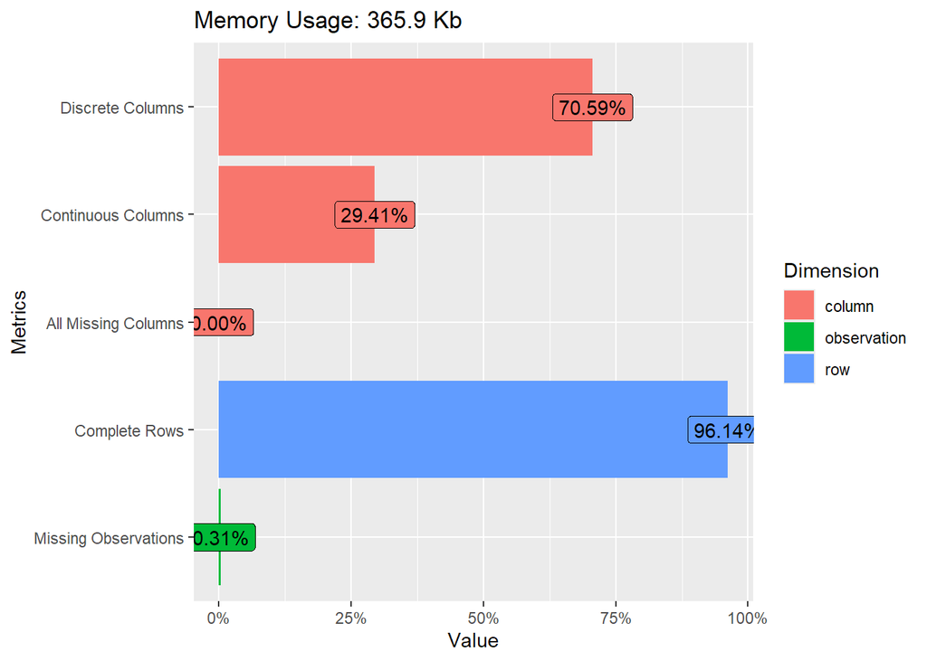

```r
plot_intro(df)
```

y con plot_missing vemos la situación variable por variable

#### Chequeo de casos perdidos

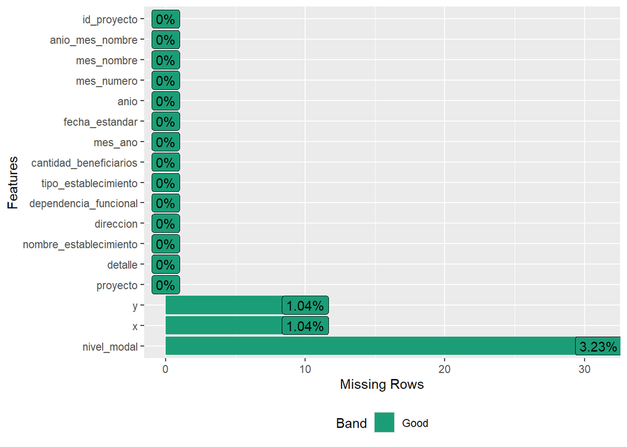

```r
plot_missing(df)
```

#### Graficos de barras

Exploramos la distribución de las variables

```r
df_subset_categoricas <- df %>% select(variables_categoricas)
```

[figure not shown]

```r
plot_bar(df_subset_categoricas)
```

Si quisiera hacer un analisis exploratorio cruzando por ej una variable pore otras

[figure not shown]

```r
df_subset_categoricas %>%
  plot_bar(by = "proyecto")
```

#### Histogramas

También podemos pedirle unos histogramas para las variables continuas

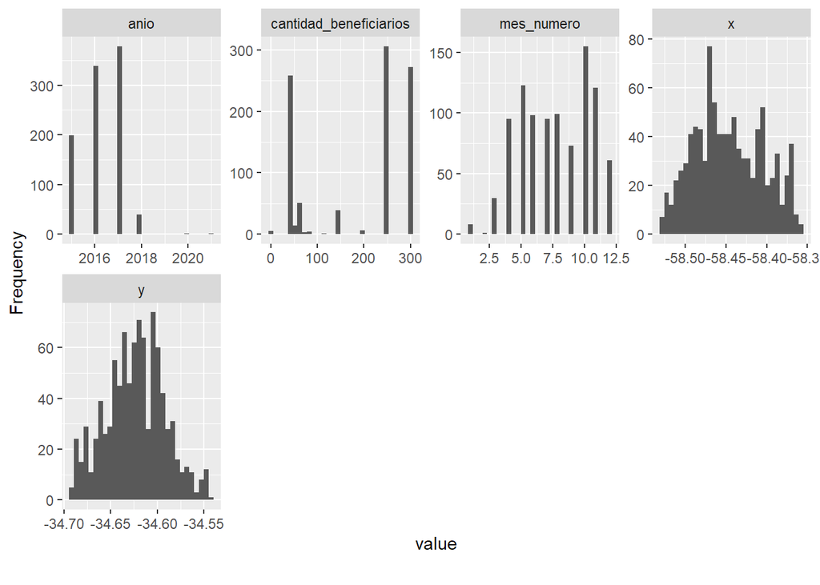

```r
plot_histogram(df)
```

Analisis de correlaciones

La correlacion indica la fuerza y la dirección de la relación lineal entre dos variables. En otras palabras, nos dice si, cuando una variable cambia, la otra tiende a cambiar en la misma dirección (correlación positiva) o en dirección opuesta (correlación negativa)

Por ej en el caso `anio` vemos que tiene una correlación de 0.47 con la cantidad de beneficiarios pero no nos indica aun con que anio (para eso tenemos que hacer un análisis dfesgregado pore cada anio) Pero si desagregamos ese anio como categórica podemos ir viendo como pierde fuerza a segun la categoría.

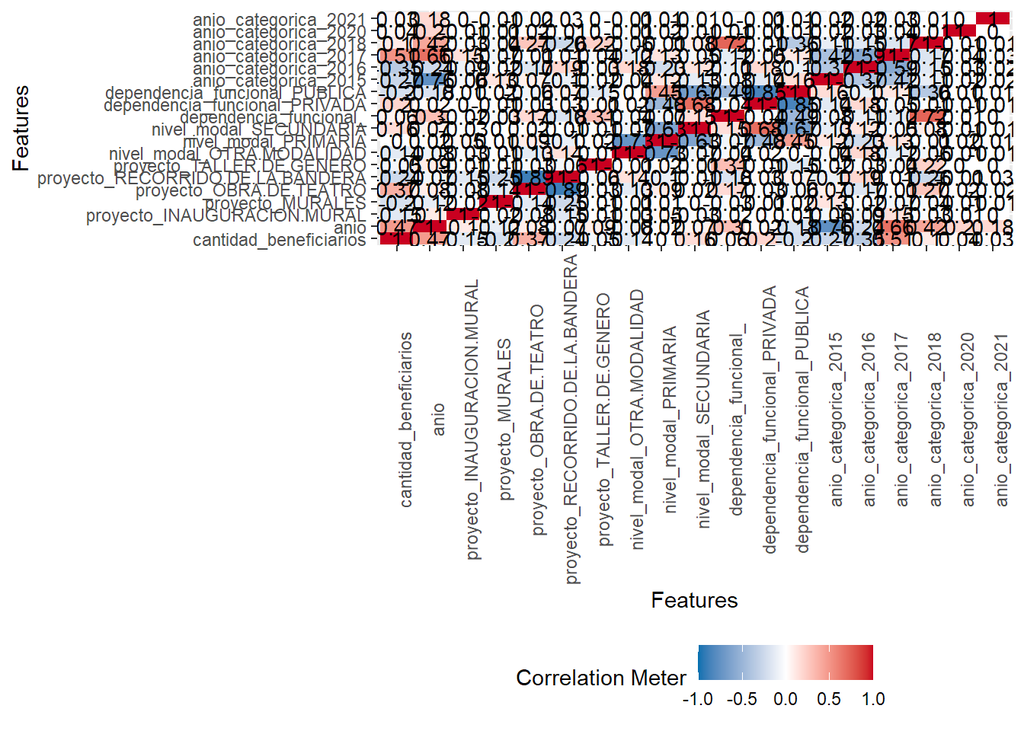

```r
df_subset_correlation <- df %>%
  mutate(anio_categorica = as.factor(anio)) %>%
  select(proyecto,nivel_modal,dependencia_funcional,cantidad_beneficiarios,anio,anio_categorica)

plot_correlation(na.omit(df_subset_correlation), maxcat = 10L) # le pido que omita los na y que el máximo de categorias a analizar sea 10
```

También podemos solamente trabajarlo con variables continuas, o solo las discretas seteando el parámetro type

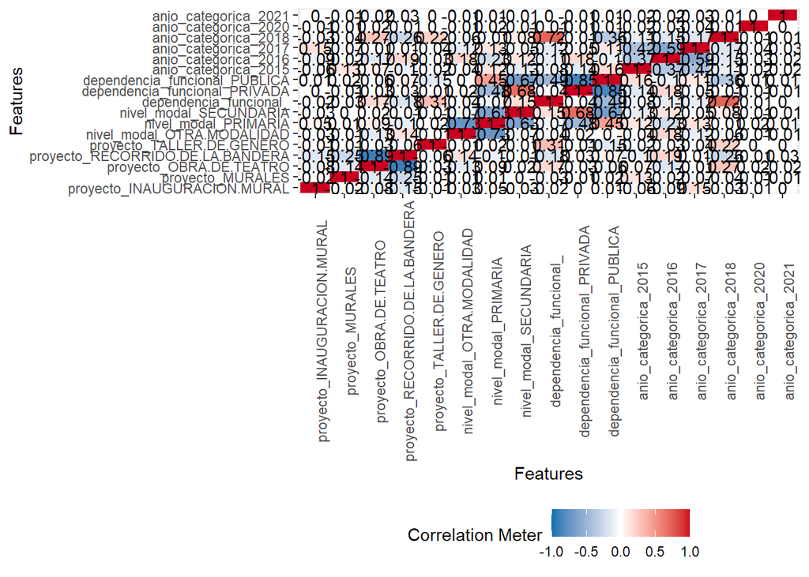

```r
plot_correlation(na.omit(df_subset_correlation), maxcat = 10L,
                 type = "discrete") # me quedo solo con las discretas
```

Como es esta relación entre cantidad de beneficiarios y años

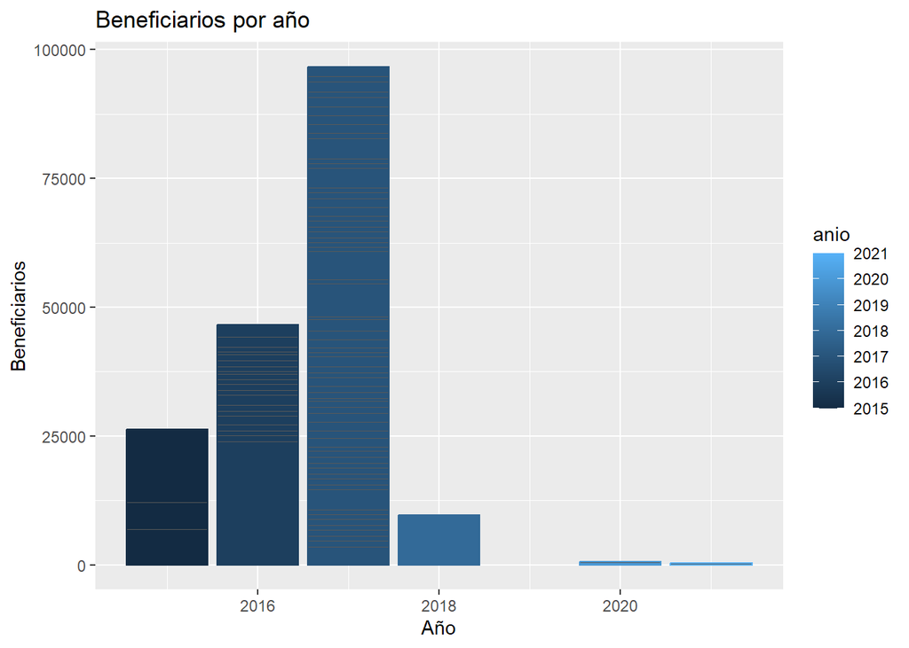

```r
ggplot(data = df) +
    geom_col(aes(x = anio, y = cantidad_beneficiarios, color = anio)) +
    labs(title = "Beneficiarios por año",
         x = "Año",
         y = "Beneficiarios")
```

La variable año es la unica que explica?

```r
lm_1 <- lm(cantidad_beneficiarios ~ anio_categorica, data = df_subset_correlation)

summary(lm_1)
```

```
Call:
lm(formula = cantidad_beneficiarios ~ anio_categorica, data = df_subset_correlation)

Residuals:
     Min       1Q   Median       3Q      Max
-255.767  -97.301   -5.767   44.233  168.166

Coefficients:
                    Estimate Std. Error t value Pr(>|t|)
(Intercept)          131.834      6.616  19.928  < 2e-16 ***
anio_categorica2016    5.467      8.334   0.656   0.5120
anio_categorica2017  123.933      8.174  15.163  < 2e-16 ***
anio_categorica2018  107.416     16.171   6.642 5.18e-11 ***
anio_categorica2020  143.166     66.321   2.159   0.0311 *
anio_categorica2021  168.166     93.559   1.797   0.0726 .
---
Signif. codes:  0 '***' 0.001 '**' 0.01 '*' 0.05 '.' 0.1 ' ' 1

Residual standard error: 93.32 on 953 degrees of freedom
Multiple R-squared:  0.2886,    Adjusted R-squared:  0.2849
F-statistic: 77.33 on 5 and 953 DF,  p-value: < 2.2e-16
```

Nuestro modelo solo está explicando el 28.4% de la variabilidad (Adjusted R-squared) con un error estándar alto de 93.32.

2017–2021 muestran aumentos importantes respecto al año base.

2016 no cambió mucho (quizás fue un año tranqui o con menor despliegue).

El modelo captura una tendencia, pero no tiene contexto: no distingue si el aumento se debe a los proyectos, a cambios institucionales, ni al tipo de población.

Agregamos entonces más variables para ver la predicción sobre la cantidad de beneficiarios en función de

- Año como variable categórica
- Tipo de proyecto
- Nivel modal
- Dependencia funcional (privada/pública)

```r
lm_2 <- lm(cantidad_beneficiarios ~ anio_categorica + proyecto + nivel_modal + dependencia_funcional, data = df_subset_correlation)

summary(lm_2)
```

```
Call:
lm(formula = cantidad_beneficiarios ~ anio_categorica + proyecto +
    nivel_modal + dependencia_funcional, data = df_subset_correlation)

Residuals:
     Min       1Q   Median       3Q      Max
-311.772  -66.946    7.283   63.694  206.612

Coefficients:
                                Estimate Std. Error t value Pr(>|t|)
(Intercept)                     -89.3248    34.8327  -2.564 0.010494 *
anio_categorica2016               0.8898     7.2328   0.123 0.902116
anio_categorica2017             129.3598     6.8960  18.759  < 2e-16 ***
anio_categorica2018              56.5689    18.7457   3.018 0.002618 **
anio_categorica2020             130.3210    54.2708   2.401 0.016535 *
anio_categorica2021             193.0539    76.5825   2.521 0.011876 *
proyectoMURALES                 125.5254    25.2789   4.966 8.17e-07 ***
proyectoOBRA DE TEATRO          269.0550    21.9116  12.279  < 2e-16 ***
proyectoRECORRIDO DE LA BANDERA 193.5891    21.6726   8.932  < 2e-16 ***
proyectoTALLER DE GENERO         78.3075    60.9252   1.285 0.199011
nivel_modalPRIMARIA              14.4483     9.7228   1.486 0.137618
nivel_modalSECUNDARIA            16.3258    17.1956   0.949 0.342658
dependencia_funcionalPRIVADA     92.9153    26.6886   3.481 0.000522 ***
dependencia_funcionalPUBLICA    -11.7666    25.4789  -0.462 0.644324
---
Signif. codes:  0 '***' 0.001 '**' 0.01 '*' 0.05 '.' 0.1 ' ' 1

Residual standard error: 76.34 on 914 degrees of freedom
  (31 observations deleted due to missingness)
Multiple R-squared:  0.5332,    Adjusted R-squared:  0.5266
F-statistic: 80.32 on 13 and 914 DF,  p-value: < 2.2e-16
```

Los proyectos artísticos (especialmente el teatro) convocan multitudes, y eso es visible incluso en modelos estadísticos. Los años 2017 y 2020 tuvieron momentum para el programa. La escuela privada parece tener más poder de convocatoria. Pero ojo, hay bastante que aún no se explica —este modelo explica bien, pero no todo.

## Más ejemplos

https://datosgcba.github.io/curso-datos/trabajos/asistentes_ctba.html